# R u Ready? HS2025 | Psychologie der Digitalisierung - Einheit 2

Sandra Grinschgl, Aaron Friedli, Lars Schilling

## R u Ready? Reprodzierbare Datenaufbereitung und -analyse mit R

HS 2025  
**LV-Leitung**: Dr. Sandra Grinschgl / MSc. Aaron Friedli  
**Tutor**: BSc. Lars Schilling  
**2. Einheit**, 24.09.2025

## Semesterplan

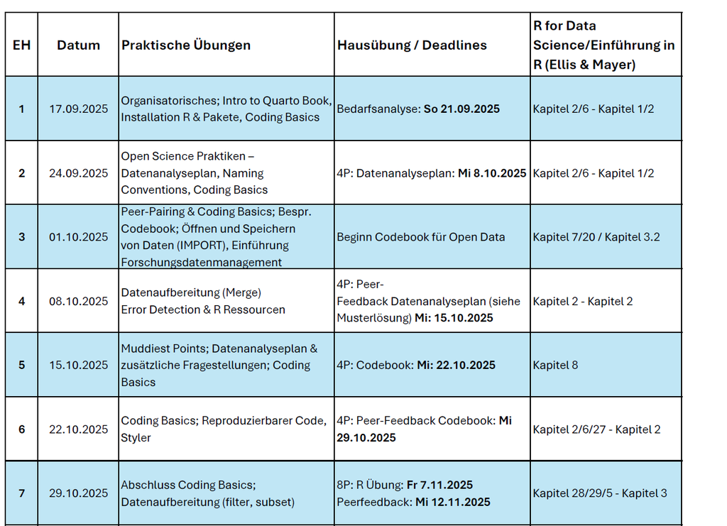

## Ergebnisse der Bedarfsanalyse (1)

**10:15 (*N* = 24)**

*Wie würdest du aktuell deine R-Kenntnisse einschätzen?*

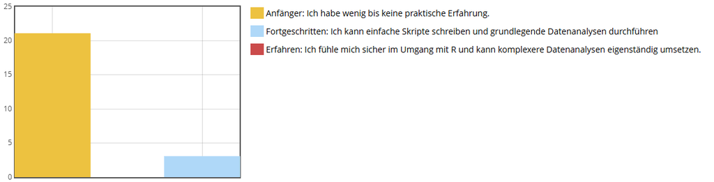

**16:15 (*N* = 23)**

*Wie würdest du aktuell deine R-Kenntnisse einschätzen?*

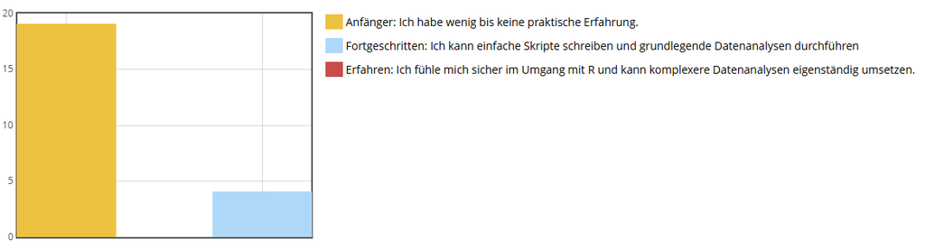

## Ergebnisse der Bedarfsanalyse (2)

*Wie oft hast du R schon verwendet?*

**10:15**

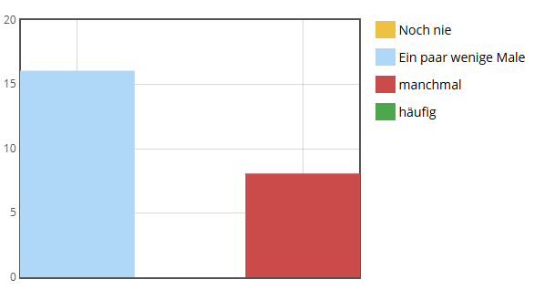

*Wie oft hast du R schon verwendet?*

**16:15**

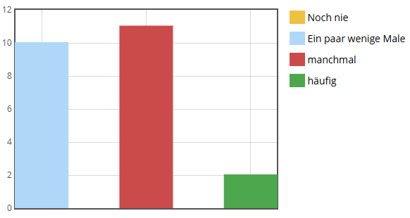

## Ergebnisse der Bedarfsanalyse (3)

**In welchen Lehrveranstaltungen hast du R verwendet?**

- Statistik
- Diagnostik
- Neuowissenschaften/Computerlab
- Bachelorarbeit/Masterarbeit
- Weitere Kurse und Seminar ( z.B. Datensatzaufbereitung in R)

## Ergebnisse der Bedarfsanalyse (4)

**Hast du R auch außerhalb von Lehrveranstaltungen verwendet?**

**10:15**

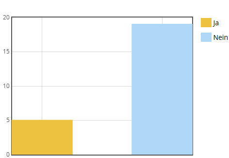

**Hast du R auch außerhalb von Lehrveranstaltungen verwendet?**

**16:15**

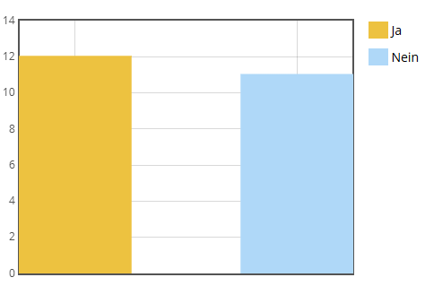

## Ergebnisse der Bedarfsanalyse (5)

**Welche R-Pakete hast du bereits verwendet?**

- Fast alle von euch haben schon mit dem Tidyverse gearbeitet

## Ergebnisse der Bedarfsanalyse (6)

**Wie unsicher fühlst du dich im Umgang mit den folgenden Themen?**

**10:15**

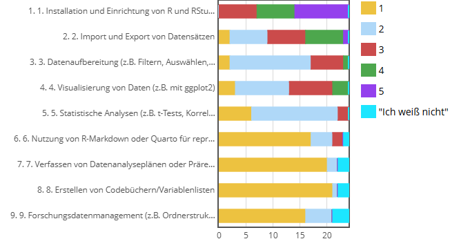

**Wie unsicher fühlst du dich im Umgang mit den folgenden Themen?**

**16:15**

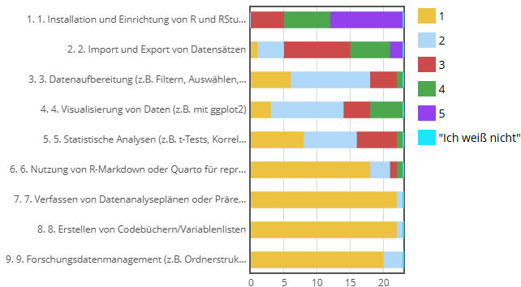

## Ergebnisse der Bedarfsanalyse (7)

**Welche weiteren Schritte bereiten dir Schwierigkeiten in R?**

- Allgemeine Unsicherheit / Überforderung
- Grundlegendes, Syntax & Fehleranalyse (Code funktioniert nicht)
- Pakete und Funktionen (Wann brauche ich was?)
- Codes schreiben und verstehen (Eigenständig coden, nachvollziehen von generiertem Code)
- Datenverständnis & -aufbereitung
- Statistische Analysen & Anwendungen
- Ganzheitliches Verständnis von Code

## Ergebnisse der Bedarfsanalyse (8)

Bei welchen Schritten in R **fühlst du dich sicher**, wenn du auch daran denkst, die im Bachelor erworbenen Unterlagen zu Hilfe zu ziehen?

- Basics (z.B. Vektoren zuweisen)
- Datenimport & -aufbereitung
- Deskriptive & einfache Analysen
- Visualisierung mit ggplot2
- Fortgeschrittene Analysen mit bereits vorbereiteten Daten
- Allgemeine Unsicherheit ➡️ mit Unterlagen, KI, oder Schritt für Schritt Anweisungen funktioniert bereits einiges

## Ergebnisse der Bedarfsanalyse (9)

**Was würdest du gerne in diesem Methodenseminar lernen?**

- Grundlagen und Verständnis festigen ➡️ Sicherheit gewinnen
- Datenaufbereitung
- Statistische Analysen und Interpretation
  - Wann brauche ich welche Tests ➡️ Leider kann keine grundlegende Statistik-Auffrischung angeboten werden.
  - Aber: Strukturiertes Vorgehen z.B. Datenanalyseplan.
- Visualisierung und Dokumentation
- Eigenständiger werden & Problemlöseskills
- Motivation und Sicherheit!

## Ergebnisse der Bedarfsanalyse (10)

**Welche Unterstützung um die Datenaufbereitung und -analyse in R würdest du dir innerhalb dieses Seminars wünschen?**

- offene Fehlerkultur
- Schritt-für-Schritt-Anleitungen im individuellen Tempo → **Musterlösungen**
- Üben und Praxis ➡️ **Hands-on!**
- Niederschwellige Hilfe ➡️ **Tutor, Sprechstunden**
- Verknüpfung von „Warum“ und „Wie“ ➡️ **konzeptionelle und praktische Kompetenz**

## Ergebnisse der Bedarfsanalyse (11)

Welche Unterstützung um die Datenaufbereitung und -analyse in R würdest du dir außerhalb dieses Seminars (z.B. im Studium allgemein) wünschen?

- Anlaufstellen & Beratung ➡️ Methodenberatung, Foren für Mitstudierende
- Skripte & Materialien ➡️ Frei Zugängliche Skripte, Templates, Cheat-Sheets
- Kurse & Übungsangebote ➡️ Zusätzliche Kurse für Auffrischung und Übung
- Praxis & Anwendung im Studium ➡️ R stärker in VLs und Seminare & Projekte einbinden um Routine zu entwicklen
- Theorie-Verknüpfung & Verständnis

## Peer-Pairing:

**10:15**

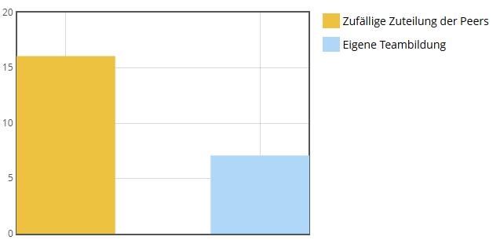

**16:15**

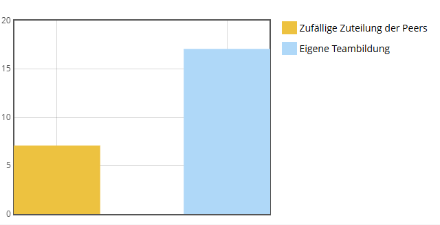

## Peer-Pairing:

- Vorgehen: Melden bis **Sonntag 28.09** **(ILIAS Forum**, siehe EH2) mit Namen des 2er Teams
- Ansonsten: Zufällige Zuteilung am Montag - Kennenlernen in der nächsten Einheit

[figure not shown]

Illustration von Freepik

## Open Science - Menti

[figure not shown]

## Replikationskrise

- Ausgangspunkt: 9 Studien, die darauf hinweisen, dass Personen «in die Zukunft sehen können» (Bem , 2011)
- Etablierte psychologische Messmethoden (z.B. Priming)
- Ein Ergebnis: Primes, die nach Antwort präsentiert werden, beeinflussen Antwortzeiten
- Starke Kritik, v.a. was Methodik betrifft; gerade kontroverse,„unwahrscheinliche“ Hypothesen sollten durch strikte, konfirmatorische Analysen überprüfen (Francis, 2012; LeBel & Peters, 2011; Wagenmakers et al., 2011)
- Diverse gescheiterte Replikationsversuche (Galak et al., 2012; Ritchie et al., 2012; Robinson, 2011)

## Replizierbarkeit und Reproduzierbarkeit

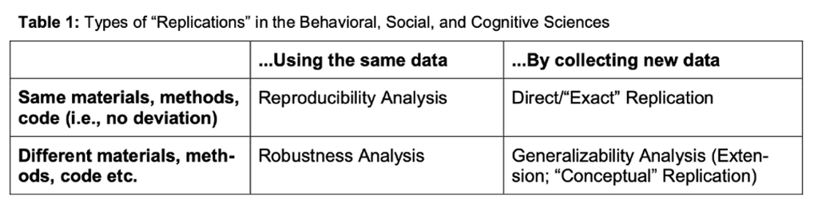

Schönbrodt, 2023

## Open Science Collaboration (2015)

Gemeinsames Projekt von 270 Autor:innen, mit dem Ziel 100 Studien aus drei verschiedenen Journals zu replizieren.

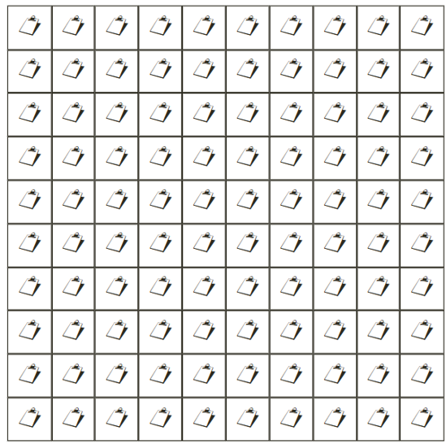

## Open Science Collaboration (2015)

- Signifikante Ergebnisse in den Original-Studien: **97%**
- Wie viele % der Effekte liessen sich replizieren - was glaubt ihr?

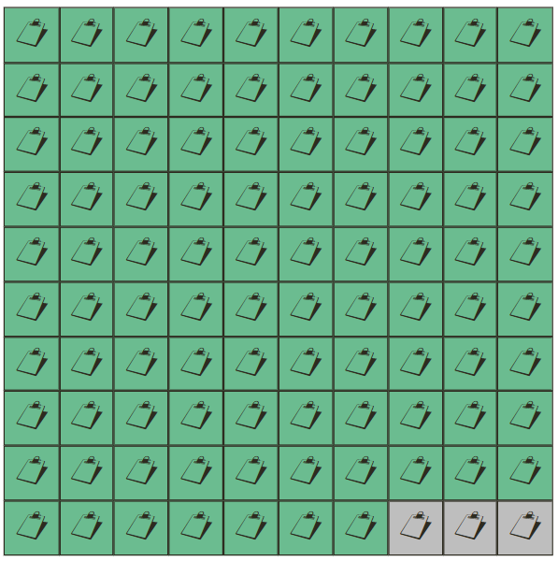

## Open Science Collaboration (2015)

- Signifikante Ergebnisse in den Replikationsstudien: **36%**
- Die Effektgrössen in den Replikationsstudien sind im Schnitt halb so gross!

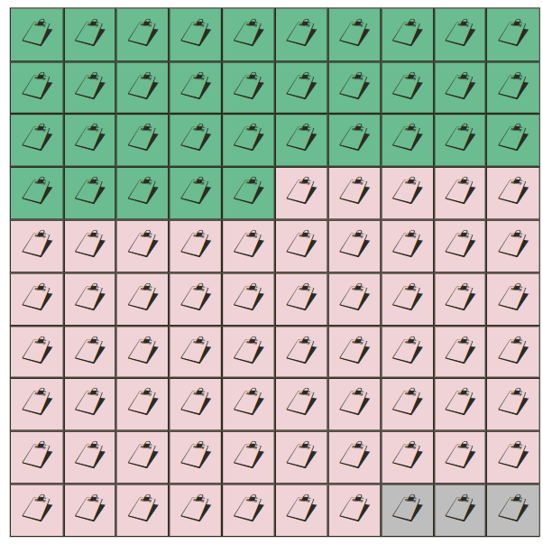

## Replikationskrise in anderen Fächern

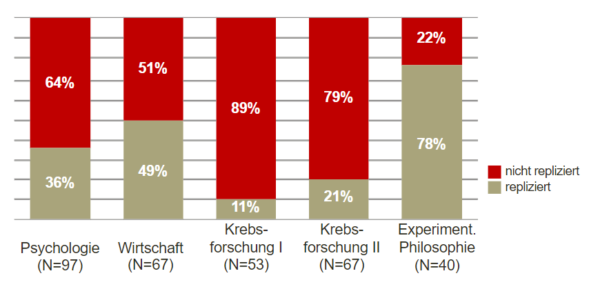

Schönbrodt, 2023; Hofer, 2024

*Bei Wirtschaft geht es um Reproduzierbarkeit.

Siehe auch: https://www.youtube.com/watch?v=FpCrY7x5nEE&ab_channel=TED-Ed

## Warum?

## Gründe für die Replikationskrise:

- **Akademisches Umfeld:**
  - Quantität > Qualität
  - “publish or perish”
- **Questionable Research Practices:**
  - Selektive Berichterstattung
  - *p*-hacking
- **Biases:**
  - Confirmation Bias
  - Publication Bias

“If you torture data long enough, it will confess to anything” - Ronald Coase

(Spielt natürlich auch eine Rolle: Versuchsmethoden und Zufallsbefunde)

## Gründe für die Replikationskrise:

Chambers, C. (2017). The seven deadly sins of psychology: A manifesto for reforming the culture of scientific practice. Princeton University Press. https://doi.org/10.1515/9781400884940

## Aktuelle Fälle:

[**Top German psychologist fabricated data, investigation finds**](https://www.science.org/content/article/top-german-psychologist-fabricated-data-investigation-finds)

- Der bekannte Psychologe Hans-Ulrich Wittchen soll in einer millionenschweren Studie Daten gefälscht und Whistleblower unter Druck gesetzt haben, was nun zu strafrechtlichen Ermittlungen und möglichen Sanktionen führt.

[**“Here’s the Unsealed Report Showing How Harvard Concluded That a Dishonesty Expert Committed Misconduct”**](https://statmodeling.stat.columbia.edu/2024/03/14/heres-the-unsealed-report-showing-how-harvard-concluded-that-a-dishonesty-expert-committed-misconduct/)

- Die Forscherin Francesca Gino wird beschuldigt, Daten in mehreren Studien manipuliert zu haben, bestreitet jedoch die Vorwürfe und führt sie auf mögliche Fehler oder andere Personen zurück.

[**A Scandal in Alzheimer’s Research Shows How Science Can Go Astray**](https://www.chronicle.com/article/a-scandal-in-alzheimers-research-shows-how-science-can-go-astray)

- Eine Untersuchung legt nahe, dass eine einflussreicher Alzheimer-Studie von 2006 manipulierte Bilder enthielt, was Zweifel an jahrelanger Forschung und der wissenschaftlichen Integrität aufwirft.

## Retraction Watch Leaderboard

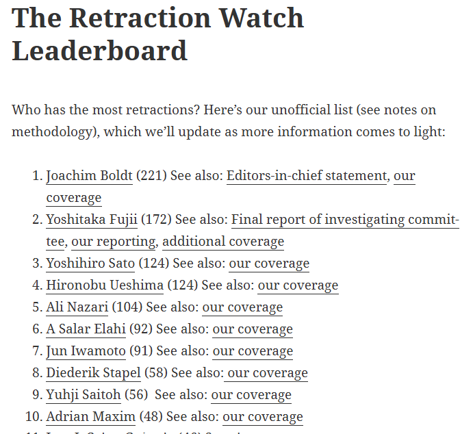

## THE END IS NEAR

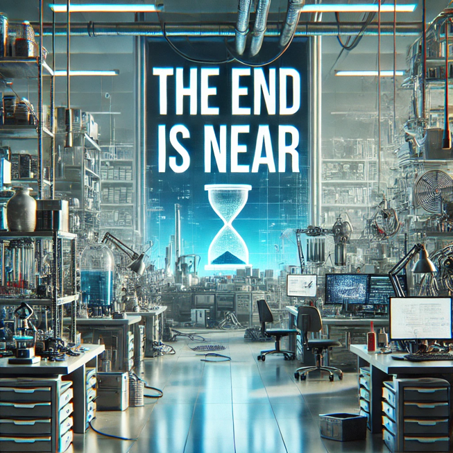

Bild generiert von ChatGPT Image Generator

- **Oder?**
- *„Science is never perfect, but what this crisis has shown is that there is never a shortage of scientists who will keep trying to make it better.”* (Maki Naro)

## Lösungsansätze - Open Science

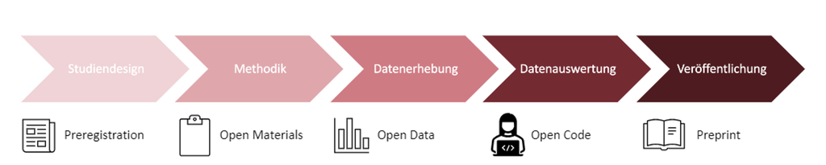

Auch wichtig: Registered Reports und Replikationsstudien; Open Acces Publikationen, Open Peer Review, Educational Practices

## Lösungsansätze - Open Science (2)

- Präregistrierung
  - Festlegung der zentralen Aspekte der Studie (z.B. Hypothesen, Stichprobe, Analyse) vor ihrer Umsetzung (d.h. **vor der Datenerhebung**)
  - Auch möglich **vor der Datenanalyse** —> Datenanalyseplan
  - Präregistrierung wird veröffentlicht, erhält einen Zeitstempel und ist schreibgeschützt
    - www.osf.io
    - [Verschiedene Templates](https://help.osf.io/article/229-select-a-registration-template)
- Preprints:
  - Version des Manuskripts vor Peer-Review
  - Postprint: Version des Manuskripts nach Peer Review.

[figure not shown]

## Lösungsansätze - Open Science (2)

Open Material, Data & Code

- **Open Material:** Untersuchungsmaterial (Fragebogen, Stimuli, usw.) wird online zur Verfügung gestellt
- **Open Data:** Daten werden in **anonymisierter** Form veröffentlicht
- **Open Code:** Reproduzierbare Analyseskripte werden zur Verfügung gestellt

Badges:

[figure not shown]

Erlaubt Ergebnisse zu überprüfen; erhöht die Glaubwürdigkeit an Forschung; stärkt die gefundenen Ergebnisse

## Open Science = Gute wissenschaftliche Praxis

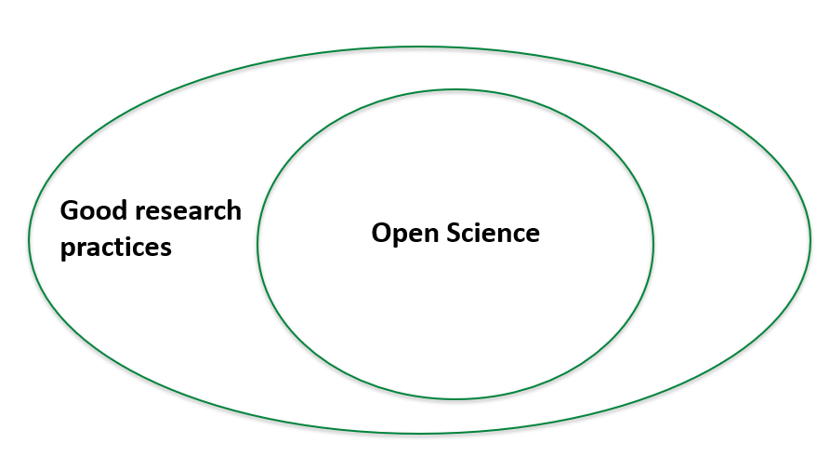

Stefan et al. (2023)

## Weitere Ressourcen:

- Pennington, C. R. (2023). A student’s guide to open science: Using the replication crisis to reform psychology. McGraw Hill.
- Open Science an der Universität Bern: https://www.ub.unibe.ch/service/open_science/index_ger.html
- Blogs über aktuelle Themen: https://datacolada.org
- Journal Club: https://reproducibilitea.org
- Comic: https://thenib.com/repeat-after-me/?utm_campaign=web-share-links&utm_medium=social&utm_source=link
- Lehrveranstaltungen der Abteilung „Psychologie der Digitalisierung“- Meta-Wissenschaft https://www.dig.psy.unibe.ch/studium/lehrveranstaltungen/index_ger.html

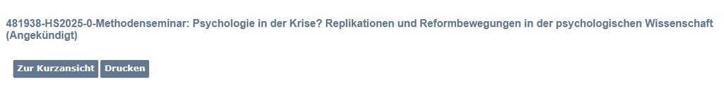

- „Spellchecker“ für Statistik https://michelenuijten.shinyapps.io/statcheck-web/

## Was bedeutet dies nun für uns?

- Festhalten der Analysen in Datenanalyseplänen
- Analyse reproduzierbar gestalten ➡️ durch Kommentierung von Code, Codebook etc.
- Idealerweise: auch bei der Masterarbeit Präregistrierung oder Datenanalyseplan etc. (Unterstützung dafür bietet auch die Methodensprechstunde bei Aaron)
- Regt eure Betreuer:innen an!

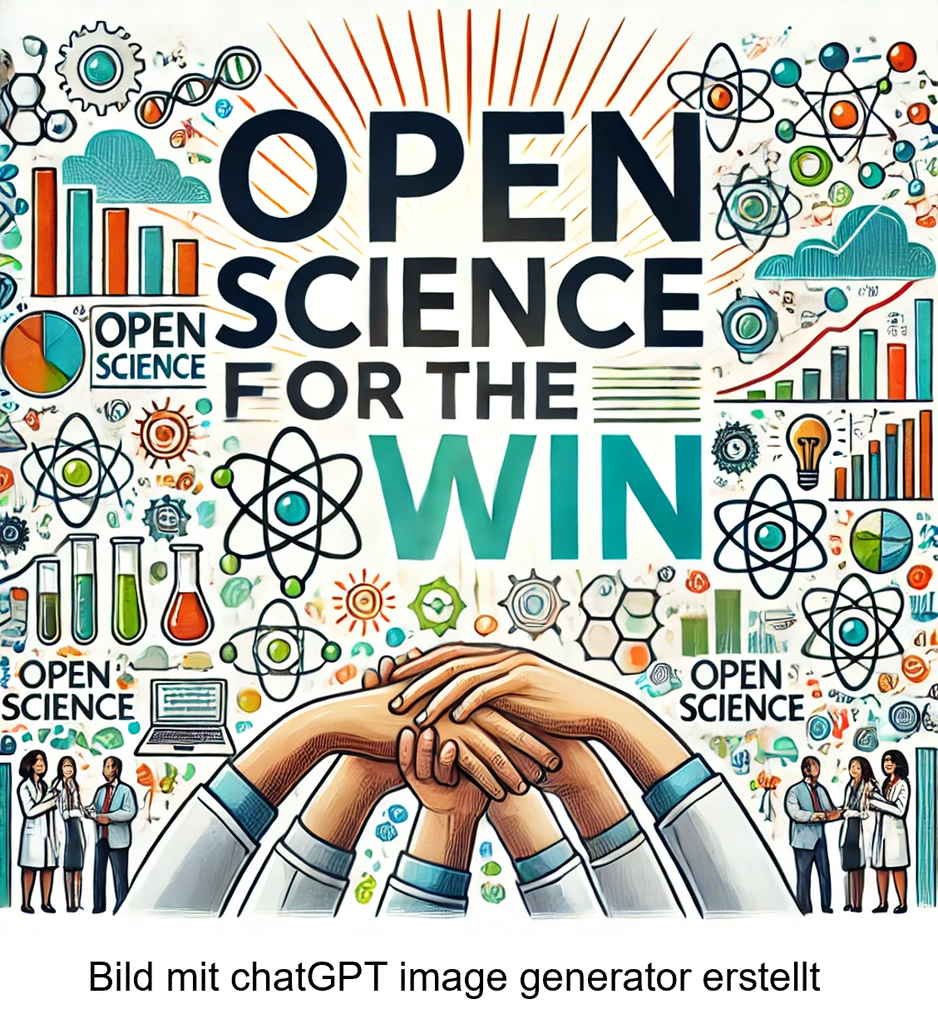

## Präregistrierung/Datenanalysepläne

- Vorteile, u.a.:
  - kann davor festhalten, was ich erwarte und wie ich es analysiere = erhöhte Transparenz
  - verringerte Möglichkeiten von p-hacking, HARKing, und Biases Stichprobengröße wird festgeschrieben und muss begründet werden
  - Unterscheidung konfirmatorischer und explorativer Forschung
    - konfirmatorisch: Eine vorab festgelegte Theorie & Hypothese testen
    - explorativ: neue Zusammenhänge/Unterschiede entdecken; keine Annahmen vorab

  **“Its a plan, not a prison” (Pennington, 2023)**

### Konzeptionelle Kompetenz: Was muss ich bei der Datenaufbereitung tun, Warum muss ich dies tun

- **Welche Hypothesen möchte ich testen?**
- Stichprobe (inkl. Poweranalyse)
- Berechnung der abhängigen Variablen
- Datenausschluss
- Umgang mit fehlenden Daten, Umgang mit Ausreißern
- **Wie (d.h. mit welchem statistischen Modell) teste ich meine Hypothesen?**  
  Welche **Voraussetzungen** sind dabei zu beachten und wie gehe ich bei Verletzungen dieser vor?  
  Welche **Inferenz-Kriterien** ziehe ich heran?
- ➡️ Verringerung der “Researcher Degrees of Freedom”
- ➡️ Wichtig für alle empirischen Arbeiten! Wenn man diese Punkte vor der Datenerhebung gut durchdenkt, spart man sich bei der Analyse viel Aufwand.
- ➡️Greift auf eure Statistik-Kenntnisse und die Unterlagen aus dem Bachelor zurück!

## Präregistrierung/Datenanalysepläne

**Nachteile?**

## Grundlegender Artikel: Grinschgl et al. (2020)

*From metacognitive beliefs to strategy selection: does fake performance feedback influence cognitive offloading?*

- 3 Gruppen und mehrere Messzeitpunkte
- between-within Design
- Hauptanalysen: ANOVAs und t-Tests
- Verschiedene AVs (z.B. cognitive offloading, Arbeitsgedächtnisfähigkeiten, Selbsteinschätzung)
- Präregistriert auf OSF https://osf.io/9hpz5
  - ACHTUNG: Kein optimales Beispiel, an manchen Stellen zu knapp!

## Datenanalyseplan - (Modifizierte) Fragen

- Titel
- Kurzbeschreibung der Studie
- Forschungsfragen
- Hypothesen & explorative Fragestellungen
- Datenzugang
- Datenerhebung
- Unabhängige Variablen
- Abhängige Variablen
- Fehlende Daten
- Datenausschluss
- Vorkenntnisse zu den Daten
- Statistische Modelle
- Inferenz-Kriterien

**Diese Fragen sind für die Analysen von Grinschgl et al, (2020) zu beantworten –> erste HÜ**

## Datenanalyseplan - Aufgabenstellung

- Datenanalyseplan für Reproduzierung der Analysen von Grinschgl et al. (2020) erstellen (bis EH 4) ➡️4 Punkte
  - Paper befindet sich ohne und mit Hinweisen auf ILIAS (Ordner «Abschlussprojekt» ➡️ Zip Ordner)
  - Auf Deutsch oder Englisch
  - Nicht nur Kopie der Textteile aus dem Paper, sondern in eigene Worte fassen
  - Es gibt nicht die EINE richtige Lösung
  - Einfach mal probieren! Korrektheit zweitrangig!
- Musterlösung & Peer-Review (Zwischen EH 4-5) ➡️ 4 Punkte
- Abschlussarbeit: überarbeiteten Datenanalyseplan mit abgeben (Basis: Simulierte Daten) ➡️ Teil der 46 Punkte (Abschlussarbeit)
- FAQ anschauen, Ilias Forum für neue Fragen nutzen

## **Ankündigung: Collegium Generale**

[figure not shown]

## Ankündigung: Masterarbeit / Praktikum zu vergeben

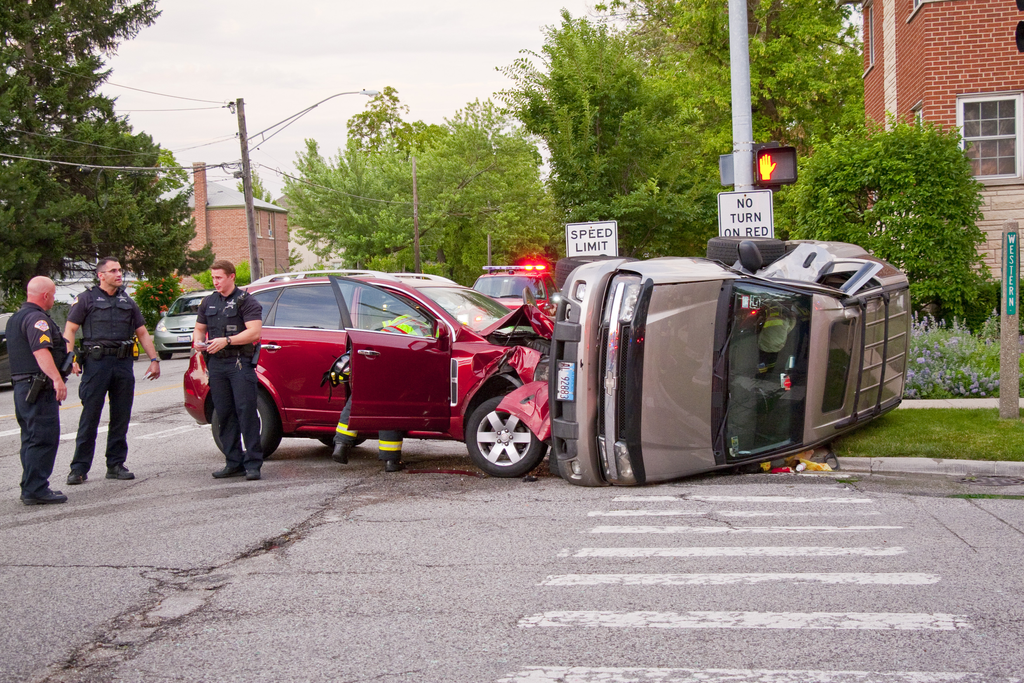

Replikationsstudie von [Loftus und Palmer](https://www.simplypsychology.org/loftus-palmer.html)(1974) Car Crash Experiment

Loftus, E. F., & Palmer, J. C. (1974). [Reconstruction of auto-mobile destruction](http://www.hss.caltech.edu/courses/2004-05/winter/psy130/LoftusPalmer.pdf): An example of the interaction between language and memory. *Journal of Verbal Learning and Verbal behavior*, 13, 585-589.

## **Heute haben wir:**

- Den Ursprung und Gründe der Replikationskrise kennengelernt
- Das Verbessern psychologischer Forschung mittels Open Science Praktiken diskutiert
- Das Konzept der Präregistrierung und des Datenanalyseplans kennengelernt
- Weitere Hands-On Übungen zu R Basics bearbeitet

## Hausübungen:

- Paper lesen (r_you_ready/Grinschgl2020/reports)
- Datenanalyseplan für Paper erstellen (auf Basis des Papers)
  - Abgabe via ILIAS, **Deadline: 08.10.2025**
  - Weiterleiten an Peer-Partner (EH4)
- Unterstützende Dokumente (Ordner: r_you_ready/Unterstützende_Dokumente/Datenanalyseplan):
  - Artikel Van den Akker et al. (2021)
  - Forum & Peer Pairing (ab EH3)
  - FAQ
  - Fragen zur nächsten Einheit mitbringen
- Hands-On Übungen (Musterlösungen nächste Woche)
- Peer-Pairings melden, **Deadline 28.09.2025**

## Referenzen:

Bem, D. J. (2011). Feeling the future: Experimental evidence for anomalous retroactive influences on cognition and affect. *Journal of Personality and Social Psychology, 100*, 407–425. https://doi.org/10.1037/a0021524

Francis, G. (2012). Too good to be true: Publication bias in two prominent studies from experimental psychology. *Psychonomic Bulletin & Review, 19*, 151–156. https://doi.org/10.3758/s13423-012-0227-9

Galak, J., LeBoeuf, R. A., Nelson, L. D., & Simmons, J. P. (2012). Correcting the past: Failures to replicate psi. *Journal of Personality and Social Psychology, 103*(6), 933–948. http://dx.doi.org/10.1037/a0029709

Grinschgl, S., Meyerhoff, H. S., Schwan, S., & Papenmeier, F. (2021). From metacognitive beliefs to strategy selection: Does fake performance feedback influence cognitive offloading? *Psychological Research, 85*, 2654–2666. https://doi.org/10.1007/s00426-020-01435-9

Hofer, G. (2024, April 23). *Open Science* [Course presentation]. University of Graz.

LeBel, E. P., & Peters, K. R. (2011). Fearing the future of empirical psychology: Bem’s (2011) evidence of psi as a case study of deficiencies in modal research practice. *Review of General Psychology, 15*(4), 371–379. https://doi.org/10.1037/a0025172

Open Science Collaboration. (2015). Estimating the reproducibility of psychological science. *Science, 349*(6251), Article aac4716. https://doi.org/10.1126/science.aac4716

Pennington, C. R. (2023). *A student’s guide to open science: Using the replication crisis to reform psychology*. McGraw Hill.

Ritchie, S. J., Wiseman, R., & French, C. C. (2012). Failing the future: Three unsuccessful attempts to replicate Bem’s ‘Retroactive Facilitation of Recall’ effect. *PloS One, 7*(3), Article e33423. https://doi.org/10.1371/journal.pone.0033423

Robinson, E. (2011). Not feeling the future: A failed replication of retroactive facilitation of memory recall. *Journal of the Society for Psychical Research, 75*, 142–147.

Schönbrodt, F. (2023). *Open Science: An overview and first easy steps*. https://osf.io/nf2rg

Stefan, A. M., Schönbrodt, F., & Schiestel, L. (2023). *An introduction to Open Science*. https://osf.io/vza25

Wagenmakers, E.-J., Wetzels, R., Borsboom, D., & van der Maas, H. L. J. (2011). Why psychologists must change the way they analyze their data: The case of psi: Comment on Bem (2011). *Journal of Personality and Social Psychology, 100*(3), 426–432. https://doi.org/10.1037/a0022790

Van Den Akker, O. R., Weston, S., Campbell, L., Chopik, B., Damian, R., Davis-Kean, P., Hall, A., Kosie, J., Kruse, E., Olsen, J., Ritchie, S., Valentine, K., Van ’T Veer, A., & Bakker, M. (2021). Preregistration of secondary data analysis: A template and tutorial. *Meta-Psychology, 5*. https://doi.org/10.15626/MP.2020.2625